# L’âge au premier alcool

Author

Kacer Mathis, Leal-Fernandes Marylou

# Introduction

L’objectif de ce rapport est de prédire les déterminents de l’âge au premier alcool, à partir de la base de données ESCAPAD 2017. Avant de mettre en place différents modèles de prédiction et de les comparer, nous allons commencer par analyser rapidement notre jeu de données et notre variable cible.

# Chargement des données

```python
import sys
from pathlib import Path

import matplotlib.pyplot as plt
import numpy as np
import pandas as pd
from matplotlib.colors import LinearSegmentedColormap

# Permet d'importer le package data depuis le dossier du projet
ROOT = Path.cwd() if (Path.cwd() / "data").is_dir() else Path.cwd().parent

if str(ROOT) not in sys.path:
    sys.path.insert(0, str(ROOT))

from data import load_escap_data
from data.labels import (
    ALCOOL_PARENT,
    NON_CONCERNE,
    NON_REPONDU,
    PREDICTORS,
    TARGET,
    VARIABLES,
    WEIGHT,
)
from data.preprocess import (
    AGE_MAX,
    SITUATION,
    SITUATION_VARS,
    TARGET_CLASS,
    build_situation,
    clean_target,
    discretize_target,
    encode_missing,
    target_thresholds,
)

pd.set_option("display.width", 200)
pd.set_option("display.max_columns", 50)

# Palette : une couleur principale, une secondaire, des gris pour le reste.
BLUE = "#2a78d6"
ORANGE = "#eb6834"
GREY = "#8a8985"
TEXT = "#52514e"

# Rampe séquentielle bleue (clair -> foncé) pour les variables ordinales.
BLUE_RAMP = ["#cde2fb", "#86b6ef", "#3987e5", "#1c5cab", "#0d366b"]

plt.rcParams.update(
    {
        "figure.dpi": 110,
        "axes.spines.top": False,
        "axes.spines.right": False,
        "axes.edgecolor": GREY,
        "axes.labelcolor": TEXT,
        "axes.titleweight": "bold",
        "axes.titlesize": 11,
        "axes.labelsize": 9,
        "xtick.color": TEXT,
        "ytick.color": TEXT,
        "xtick.labelsize": 8,
        "ytick.labelsize": 8,
        "axes.grid": True,
        "grid.color": "#e4e3df",
        "grid.linewidth": 0.6,
        "axes.axisbelow": True,
        "legend.frameon": False,
        "legend.fontsize": 8,
    }
)

# Chargement des données brutes (les étapes de prétraitement sont appliquées
# au fil du rapport)
df = load_escap_data()
y = df[TARGET]
w = df[WEIGHT]
obs = y.notna()

AGE_MIN = 6  # âges plus jeunes jugés douteux
MISSING_LABEL = "Non renseigné"


def as_labels(var: str) -> pd.Series:
    """Variable catégorielle avec libellés, les NaN devenant une modalité."""
    _, labels = VARIABLES[var]
    order = list(labels.values()) + [MISSING_LABEL]
    values = df[var].map(labels).fillna(MISSING_LABEL)
    return pd.Categorical(values, categories=order, ordered=True)


def weighted_share(values: pd.Series, weights: pd.Series) -> pd.Series:
    """Part pondérée (%) de chaque modalité."""
    s = weights.groupby(values, observed=False).sum()
    return s / s.sum() * 100


def summary(values: pd.Series, weights: pd.Series) -> pd.DataFrame:
    """Effectif et part pondérée de chaque modalité."""
    return pd.DataFrame(
        {"effectif": values.value_counts(sort=False), "% pondéré": weighted_share(values, weights)}
    ).round(1)


df.head()
```

|  | A01 | Q03 | Q04 | Q04A | Q04B | Q05 | Q06A | Q06B | Q08 | Q08C | Q09A1 | Q09B1 | Q10A1 | Q10B1 | Q19A | B08A | B08B | pm17B |
| --- | --- | --- | --- | --- | --- | --- | --- | --- | --- | --- | --- | --- | --- | --- | --- | --- | --- | --- |
| 0 | 10273 | 1.0 | 2.0 | NaN | NaN | 2.0 | 1.0 | 2.0 | 1.0 | 2.0 | 1.0 | 3.0 | 6.0 | 8.0 | 13.0 | NaN | NaN | 0.42999 |
| 1 | 37216 | 1.0 | 1.0 | 2.0 | NaN | 1.0 | 2.0 | 3.0 | 1.0 | 1.0 | 1.0 | 1.0 | 2.0 | 7.0 | 14.0 | NaN | NaN | 0.42999 |
| 2 | 9527 | 1.0 | 1.0 | 1.0 | NaN | 1.0 | 1.0 | 1.0 | 1.0 | 1.0 | 1.0 | 1.0 | 6.0 | 6.0 | 11.0 | 2.0 | 1.0 | 0.44084 |
| 3 | 10279 | 1.0 | 1.0 | 1.0 | NaN | 1.0 | 1.0 | 1.0 | 1.0 | 1.0 | 1.0 | 1.0 | 6.0 | 6.0 | 14.0 | 4.0 | 2.0 | 0.44084 |
| 4 | 10282 | 1.0 | 1.0 | 1.0 | NaN | 1.0 | 1.0 | 1.0 | 1.0 | 1.0 | 1.0 | 1.0 | 2.0 | 6.0 | 15.0 | 1.0 | 1.0 | 0.44084 |

## Analyse des données

L’enquête ESCAPAD (Enquête sur la Santé et les Consommations au cours de l’Appel de Préparation à la Défense) est une étude statistique française qui mesure les consommations de substances psychoactives et la santé des jeunes. Les données sont collectées lors de la JDC (Journée Défense et Citoyenneté) réalisée par des jeunes entre 16 et 25 ans. Le questionnaire porte sur les usages de produits addictifs légaux et illégaux (tabac, alcool, cannabis, médicaments psychotropes, ecstasy, cocaïne, etc.), leur contexte de consommation et l’état de santé global des jeunes (sommeil, santé mentale, écrans…).

Le jeu de données dont nous disposons porte uniquement sur la consommation de boissons alcollisées.

### La gestion des valeurs manquantes

Notre jeu de données contient un certain nombre de valeur manquantes (présentées ci-dessous) qu’il est important de traiter.

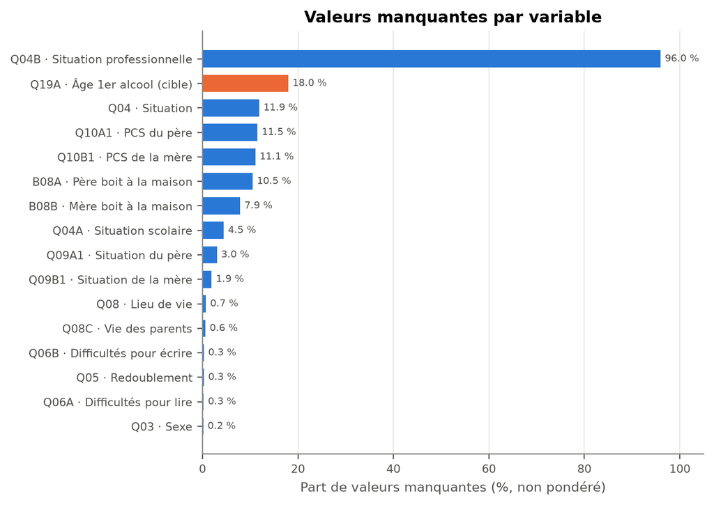

```python
na_rate = df.drop(columns=["A01", WEIGHT]).isna().mean().sort_values() * 100

fig, ax = plt.subplots(figsize=(7, 5))
colors = [ORANGE if v == TARGET else BLUE for v in na_rate.index]
bars = ax.barh(
    [f"{v} · {VARIABLES[v][0]}" if v in VARIABLES else f"{v} · Âge 1er alcool (cible)" for v in na_rate.index],
    na_rate.values,
    color=colors,
    height=0.7,
)
ax.bar_label(bars, fmt="%.1f %%", padding=3, fontsize=7, color=TEXT)
ax.set_xlabel("Part de valeurs manquantes (%, non pondéré)")
ax.set_title("Valeurs manquantes par variable")
ax.grid(axis="y", visible=False)
ax.set_xlim(0, 105)
plt.tight_layout()
plt.show()
```

Les variables qui nous préoccupent principalement sont la Q04B car elle comporte un très grand nombre de valeurs manquantes (96%) et la Q19A car il s’agit de notre variable cible (18% de NA).

Pour notre variable cible on peut considérer que les 18% de jeunes qui ne renseignent pas leur âge de première consommation ne sont tout simplement pas concernés par la question. Il s’agirait donc de jeunes qui n’ont jamais bu d’alcool. Les NA ici seront donc recodés en une nouvelle modalité : pas concerné.

Les variables Q04A “Situation scolaire” et Q04B “Situation professionnelle” présentent un fort taux de non réponse car il s’agit de variables dépendantes. Elles dépendent de la réponse à la question Q04 “Situation”. Nous allons donc pouvoir utiliser cette dépendance pour gérer les non réponses. L’idée est la suivante : Q04A n’est posée qu’à ceux qui suivent des études (Q04 = 1) et Q04B qu’à ceux qui les ont arrêtées (Q04 = 2). Si Q04 manque et qu’une seule des deux est renseignée, on en déduit Q04. Si les deux sont renseignées, on ne peut pas trancher et Q04 reste non répondu.

```python
patterns = (
    df[list(SITUATION_VARS)]
    .notna()
    .value_counts()
    .rename("effectif")
    .reset_index()
    .replace({True: "renseigné", False: "NA"})
)
patterns
```

|  | Q04 | Q04A | Q04B | effectif |
| --- | --- | --- | --- | --- |
| 0 | renseigné | renseigné | NA | 11206 |
| 1 | NA | renseigné | NA | 1495 |
| 2 | renseigné | NA | renseigné | 459 |
| 3 | NA | NA | renseigné | 58 |
| 4 | renseigné | NA | NA | 57 |
| 5 | NA | NA | NA | 19 |
| 6 | NA | renseigné | renseigné | 11 |
| 7 | renseigné | renseigné | renseigné | 9 |

```python
# Nettoyage et discrétisation de la cible (détaillés plus bas), puis situation
df1 = discretize_target(clean_target(df))
df2 = build_situation(df1)
pd.crosstab(df2["Q04"], df2["Q04A"], margins=True, margins_name="Total")
```

| Q04A Q04 | Lycée / collège | Apprentissage | Supérieur | Non concerné | Non répondu | Total |
| --- | --- | --- | --- | --- | --- | --- |
| Études | 11607 | 945 | 153 | 0 | 29 | 12734 |
| Études arrêtées | 0 | 0 | 0 | 547 | 0 | 547 |
| Non répondu | 7 | 4 | 0 | 0 | 19 | 30 |
| Total | 11614 | 949 | 153 | 547 | 48 | 13311 |

```python
pd.crosstab(df2["Q04"], df2["Q04B"], margins=True, margins_name="Total")
```

| Q04B Q04 | Sans activité | Recherche emploi | Insertion | Travaille | Non concerné | Non répondu | Total |
| --- | --- | --- | --- | --- | --- | --- | --- |
| Études | 0 | 0 | 0 | 0 | 12734 | 0 | 12734 |
| Études arrêtées | 136 | 254 | 32 | 93 | 0 | 32 | 547 |
| Non répondu | 1 | 5 | 2 | 3 | 0 | 19 | 30 |
| Total | 137 | 259 | 34 | 96 | 12734 | 51 | 13311 |

On obtient au final la variable `Situation` suivante :

```python
stats_sit = summary(df2[SITUATION], df2[WEIGHT])
stats_sit["% jamais bu"] = (
    df2.assign(nb=df2[TARGET_CLASS].eq(NON_CONCERNE) * df2[WEIGHT])
    .groupby(SITUATION, observed=False)[["nb", WEIGHT]]
    .sum()
    .pipe(lambda g: g["nb"] / g[WEIGHT] * 100)
    .round(1)
)
drinkers = df2[TARGET].notna()
stats_sit["âge moyen 1er alcool"] = (
    df2[drinkers]
    .groupby(SITUATION, observed=False)[[TARGET, WEIGHT]]
    .apply(lambda g: np.average(g[TARGET], weights=g[WEIGHT]) if len(g) else np.nan)
    .round(2)
)
stats_sit
```

| SITUATION | effectif | % pondéré | % jamais bu | âge moyen 1er alcool |
| --- | --- | --- | --- | --- |
| Études : Lycée / collège | 11607 | 87.4 | 18.7 | 14.25 |
| Études : Apprentissage | 945 | 6.9 | 12.1 | 14.44 |
| Études : Supérieur | 153 | 1.2 | 14.8 | 14.18 |
| Études : Non répondu | 29 | 0.2 | 39.5 | 14.49 |
| Arrêt : Sans activité | 136 | 1.0 | 20.3 | 14.11 |
| Arrêt : Recherche emploi | 254 | 1.9 | 20.2 | 14.66 |
| Arrêt : Insertion | 32 | 0.2 | 5.3 | 14.31 |
| Arrêt : Travaille | 93 | 0.7 | 13.5 | 14.83 |
| Arrêt : Non répondu | 32 | 0.2 | 36.6 | 14.90 |
| Non répondu | 30 | 0.2 | 27.6 | 14.94 |

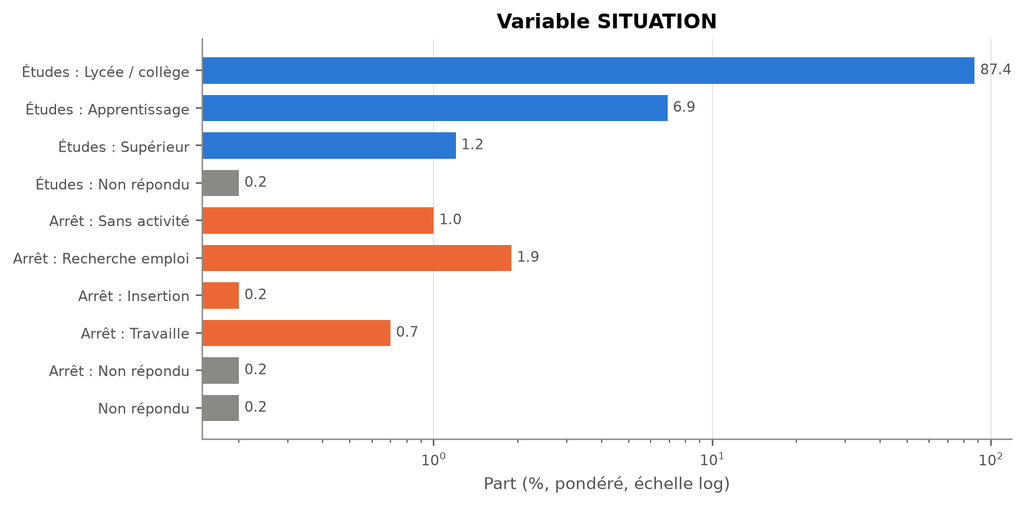

```python
fig, ax = plt.subplots(figsize=(8, 4))
colors = [GREY if NON_REPONDU in m else (BLUE if m.startswith("Études") else ORANGE)
          for m in stats_sit.index]
bars = ax.barh(stats_sit.index.astype(str), stats_sit["% pondéré"], color=colors, height=0.7)
ax.bar_label(bars, fmt="%.1f", padding=3, fontsize=8, color=TEXT)
ax.invert_yaxis()
ax.set_xscale("log")
ax.set_xlabel("Part (%, pondéré, échelle log)")
ax.set_title("Variable SITUATION")
ax.grid(axis="y", visible=False)
plt.tight_layout()
plt.show()
```

Pour les autres prédicteurs les NA seront ajouté à une nouvelle modalioté “Non répondu” car le nombre de non réponse est faible voire très faible.

```python
others = [v for v in PREDICTORS if v not in SITUATION_VARS]
df3 = encode_missing(df2, others)

na_table = pd.DataFrame(
    {
        "Non répondu (effectif)": df2[others].isna().sum(),
        "Non répondu (% pondéré)": [
            np.average(df2[v].isna(), weights=df2[WEIGHT]) * 100 for v in others
        ],
    }
).round(1)
na_table.sort_values("Non répondu (effectif)", ascending=False)
```

|  | Non répondu (effectif) | Non répondu (% pondéré) |
| --- | --- | --- |
| Q10A1 | 1535 | 11.6 |
| Q10B1 | 1473 | 11.2 |
| B08A | 1400 | 10.4 |
| B08B | 1050 | 7.9 |
| Q09A1 | 402 | 3.0 |
| Q09B1 | 256 | 2.0 |
| Q08 | 95 | 0.7 |
| Q08C | 81 | 0.6 |
| Q06B | 40 | 0.3 |
| Q05 | 40 | 0.3 |
| Q06A | 34 | 0.3 |
| Q03 | 23 | 0.2 |

### L’âge au premier alcool

Les appelés ont entre 16 et 25 ans. Un âge au premier alcool supérieur à 25 ans est donc incohérent, et les très jeunes âges (≤ 5 ans) sont douteux. On décide donc de signaler les jeunes âges sans les supprimer et de supprimer les valeurs au dessus de 25 ans.

```python
removed = df.loc[~df.index.isin(df1.index), TARGET]
print(f"{len(removed)} individus supprimés (Q19A > {AGE_MAX}) : {removed.tolist()}")
print(f"Reste : {len(df1)} individus")
```

```
3 individus supprimés (Q19A > 25) : [26.0, 32.0, 26.0]
Reste : 13311 individus
```

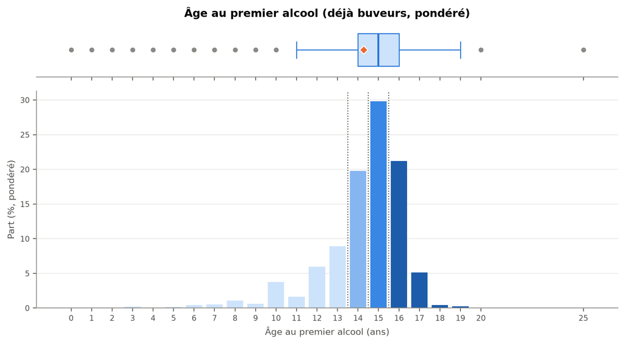

|  | Q19A |
| --- | --- |
| Effectif (déjà bu) | 10918 |
| Moyenne non pondérée | 14.291354 |
| Moyenne | 14.28026 |
| Écart-type | 2.107432 |
| Min | 0.0 |
| Q1 | 14.0 |
| Médiane | 15.0 |
| Q3 | 16.0 |
| Max | 25.0 |
| Moustaches | [11, 19] |
| Valeurs hors moustaches | 743 ind. |

```python
def weighted_quantile(values, weights, q):
    order = np.argsort(values)
    v, cw = np.asarray(values)[order], np.cumsum(np.asarray(weights)[order])
    return v[np.searchsorted(cw, np.asarray(q) * cw[-1])]


def weighted_box_stats(values, weights):
    """Statistiques d'une boîte à moustaches pondérée (format `Axes.bxp`)."""
    values, weights = np.asarray(values), np.asarray(weights)
    q1, med, q3 = weighted_quantile(values, weights, [0.25, 0.5, 0.75])
    iqr = q3 - q1
    inside = values[(values >= q1 - 1.5 * iqr) & (values <= q3 + 1.5 * iqr)]
    return {
        "med": med,
        "q1": q1,
        "q3": q3,
        "whislo": inside.min(),
        "whishi": inside.max(),
        "mean": np.average(values, weights=weights),
        "fliers": np.unique(values[(values < inside.min()) | (values > inside.max())]),
    }


obs1 = df1[TARGET].notna()
ages, w_ages = df1.loc[obs1, TARGET], df1.loc[obs1, WEIGHT]
thresholds = target_thresholds(df1)
box = weighted_box_stats(ages, w_ages)

dist = weighted_share(ages, w_ages)
class_idx = np.searchsorted(thresholds, dist.index, side="left")

fig, (ax_box, ax_hist) = plt.subplots(
    2, 1, figsize=(9, 5), sharex=True, gridspec_kw={"height_ratios": [1, 4]}
)
ax_box.bxp(
    [box],
    orientation="horizontal",
    showmeans=True,
    widths=0.6,
    patch_artist=True,
    boxprops={"facecolor": "#cde2fb", "edgecolor": BLUE},
    medianprops={"color": BLUE, "linewidth": 2},
    whiskerprops={"color": BLUE},
    capprops={"color": BLUE},
    meanprops={"marker": "D", "markerfacecolor": ORANGE, "markeredgecolor": "white"},
    flierprops={"marker": "o", "markersize": 4, "markerfacecolor": GREY, "markeredgecolor": GREY},
)
ax_box.set_yticks([])
ax_box.spines["left"].set_visible(False)
ax_box.grid(False)
ax_box.set_title("Âge au premier alcool (déjà buveurs, pondéré)")

ax_hist.bar(dist.index, dist.values, color=[BLUE_RAMP[i] for i in class_idx], width=0.8)
for t in thresholds:
    ax_hist.axvline(t + 0.5, color=TEXT, linestyle=":", linewidth=1)
ax_hist.set_xticks(dist.index.astype(int))
ax_hist.set_xlabel("Âge au premier alcool (ans)")
ax_hist.set_ylabel("Part (%, pondéré)")
ax_hist.grid(axis="x", visible=False)
plt.tight_layout()
plt.show()

pd.Series(
    {
        "Effectif (déjà bu)": len(ages),
        "Moyenne non pondérée": ages.mean(),
        "Moyenne": box["mean"],
        "Écart-type": np.sqrt(np.average((ages - box["mean"]) ** 2, weights=w_ages)),
        "Min": ages.min(),
        "Q1": box["q1"],
        "Médiane": box["med"],
        "Q3": box["q3"],
        "Max": ages.max(),
        "Moustaches": f"[{box['whislo']:.0f}, {box['whishi']:.0f}]",
        "Valeurs hors moustaches": f"{(~ages.between(box['whislo'], box['whishi'])).sum()} ind.",
    }
).to_frame("Q19A")
```

On observe une moyenne d’âge de première consommation d’alcool autour de 14 ans et une médiane autour de 15 ans. Avec une large majorité (70%) des répondants qui déclare une première consommation entre 14 et 16 ans.

### Discrétisation de l’âge au premier alcool

L’âge étant entier et très concentré, les quartiles tombent sur des valeurs répétées : pour chaque quartile, on retient l’âge dont la fonction de répartition pondérée est la plus proche, ce qui donne des classes de taille proche. Les NA deviennent « Non concerné » (jamais bu).

```python
print(f"Seuils retenus : {thresholds}")

stats_class = summary(df1[TARGET_CLASS], df1[WEIGHT])
stats_class["% pondéré parmi buveurs"] = (
    weighted_share(df1.loc[obs1, TARGET_CLASS], df1.loc[obs1, WEIGHT])
    .drop(NON_CONCERNE)
    .round(1)
)
stats_class["âge moyen"] = (
    df1[obs1]
    .groupby(TARGET_CLASS, observed=False)[[TARGET, WEIGHT]]
    .apply(lambda g: np.average(g[TARGET], weights=g[WEIGHT]) if len(g) else np.nan)
    .round(2)
)
stats_class
```

```
Seuils retenus : [13, 14, 15]
```

| Q19A_CLASSE | effectif | % pondéré | % pondéré parmi buveurs | âge moyen |
| --- | --- | --- | --- | --- |
| ≤ 13 ans | 2551 | 19.1 | 23.4 | 11.32 |
| 14 ans | 2150 | 16.2 | 19.8 | 14.00 |
| 15 ans | 3244 | 24.4 | 29.8 | 15.00 |
| ≥ 16 ans | 2973 | 22.1 | 27.0 | 16.26 |
| Non concerné | 2393 | 18.3 | NaN | NaN |

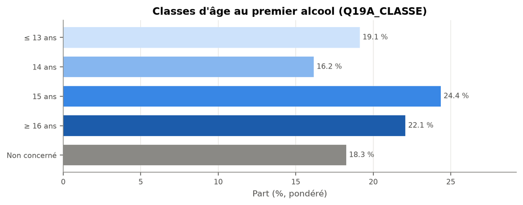

```python
shares = weighted_share(df1[TARGET_CLASS], df1[WEIGHT])
fig, ax = plt.subplots(figsize=(8, 3.2))
bars = ax.barh(shares.index.astype(str), shares.values,
               color=BLUE_RAMP[: len(shares) - 1] + [GREY], height=0.7)
ax.bar_label(bars, fmt="%.1f %%", padding=3, fontsize=8, color=TEXT)
ax.invert_yaxis()
ax.set_xlim(0, shares.max() * 1.2)
ax.set_xlabel("Part (%, pondéré)")
ax.set_title("Classes d'âge au premier alcool (Q19A_CLASSE)")
ax.grid(axis="y", visible=False)
plt.tight_layout()
plt.show()
```

### Les prédicteurs potentiels

Pour chacun des prédicteurs on observe ici les parts pondérées de chaque modalité, les non-réponses forment une modalité à part (en gris).

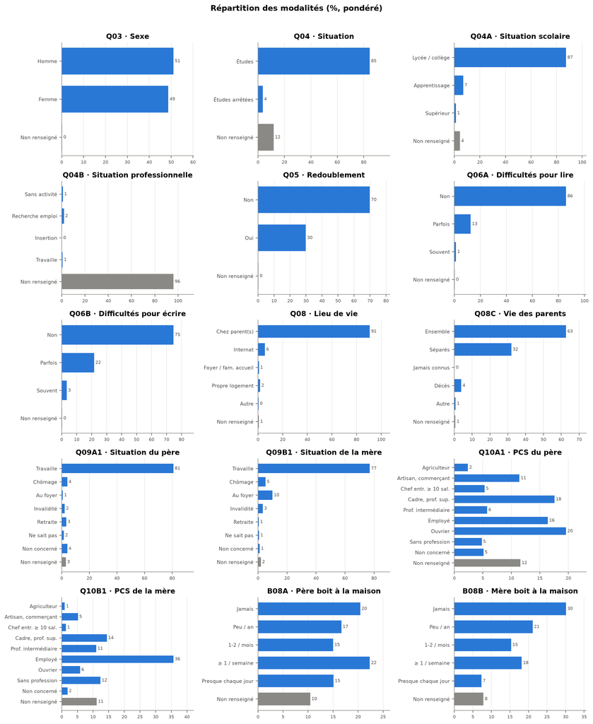

```python
def weighted_shares(var: str) -> pd.Series:
    s = pd.DataFrame({"mod": as_labels(var), "w": w}).groupby("mod", observed=False)["w"].sum()
    return s / s.sum() * 100


ncols = 3
nrows = int(np.ceil(len(PREDICTORS) / ncols))
fig, axes = plt.subplots(nrows, ncols, figsize=(13, 3.2 * nrows))
for ax, var in zip(axes.flat, PREDICTORS):
    shares = weighted_shares(var)
    colors = [GREY if m == MISSING_LABEL else BLUE for m in shares.index]
    bars = ax.barh(shares.index.astype(str), shares.values, color=colors, height=0.7)
    ax.bar_label(bars, fmt="%.0f", padding=2, fontsize=7, color=TEXT)
    ax.invert_yaxis()
    ax.set_title(f"{var} · {VARIABLES[var][0]}")
    ax.set_xlim(0, shares.max() * 1.18)
    ax.grid(axis="y", visible=False)
    ax.tick_params(axis="x", labelsize=7)
for ax in axes.flat[len(PREDICTORS):]:
    ax.remove()
fig.suptitle("Répartition des modalités (%, pondéré)", fontweight="bold")
plt.tight_layout(rect=(0, 0, 1, 0.97))
plt.show()
```

Nous avons ensuite observé le lien entre l’âge au premier alcool et chaque prédicteur. On observe ainsi une moyenne pondérée de `Q19A` par modalité, avec un intervalle de confiance à 95 % approché (taille effective de Kish). Seuls les âges dans la plage et plausible sont retenus. La ligne pointillée est la moyenne globale.

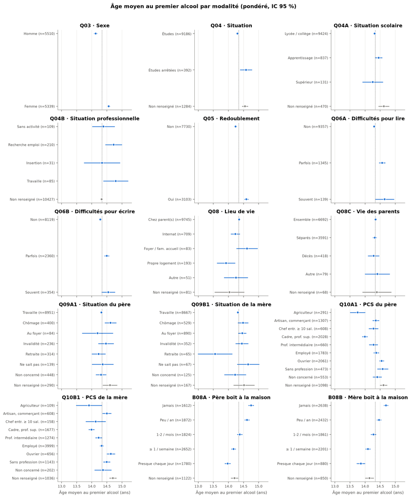

```python
clean = obs & (y >= AGE_MIN) & (y <= AGE_MAX)
mean_clean = np.average(y[clean], weights=w[clean])


def weighted_mean_ci(group: pd.DataFrame) -> pd.Series:
    yy, ww = group["y"], group["w"]
    if ww.sum() == 0:
        return pd.Series({"mean": np.nan, "ci": np.nan, "n": 0})
    m = np.average(yy, weights=ww)
    var = np.average((yy - m) ** 2, weights=ww)
    n_eff = ww.sum() ** 2 / (ww**2).sum()
    return pd.Series({"mean": m, "ci": 1.96 * np.sqrt(var / n_eff), "n": len(yy)})


def mean_by(var: str, mask=clean) -> pd.DataFrame:
    data = pd.DataFrame({"mod": as_labels(var), "y": y, "w": w})[mask]
    return data.groupby("mod", observed=False)[["y", "w"]].apply(weighted_mean_ci)


fig, axes = plt.subplots(nrows, ncols, figsize=(13, 3.2 * nrows), sharex=True)
for ax, var in zip(axes.flat, PREDICTORS):
    stats = mean_by(var)
    stats = stats[stats["n"] >= 30]  # modalités trop rares écartées
    pos = np.arange(len(stats))
    colors = [GREY if m == MISSING_LABEL else BLUE for m in stats.index]
    ax.errorbar(
        stats["mean"], pos, xerr=stats["ci"], fmt="none", ecolor=colors, elinewidth=1.5, capsize=0
    )
    ax.scatter(stats["mean"], pos, color=colors, s=28, zorder=3, edgecolor="white", linewidth=1)
    ax.set_yticks(pos, [f"{m} (n={int(n)})" for m, n in zip(stats.index, stats["n"])])
    ax.invert_yaxis()
    ax.axvline(mean_clean, color=TEXT, linestyle=":", linewidth=1)
    ax.set_title(f"{var} · {VARIABLES[var][0]}")
    ax.grid(axis="y", visible=False)
for ax in axes.flat[len(PREDICTORS):]:
    ax.remove()
for ax in axes[-1]:
    ax.set_xlabel("Âge moyen au premier alcool (ans)")
fig.suptitle("Âge moyen au premier alcool par modalité (pondéré, IC 95 %)", fontweight="bold")
plt.tight_layout(rect=(0, 0, 1, 0.97))
plt.show()
```

On observe notamment que `la consommation d'alcool des parents` semble avoir un effet important sur l’âge de la première consommation des enfants. En effet, plus la mère ou le père consomment régulièrement, plus l’enfant a tendance à consommer tôt. Cette hypothèse semble confirmée lorsque l’on croise les habitudes de consommations du père et de la mère et qu’on observe l’âge moyen de première consommation des enfants. Dans le graphique suivant les cases de moins de 30 répondants sont masquées.

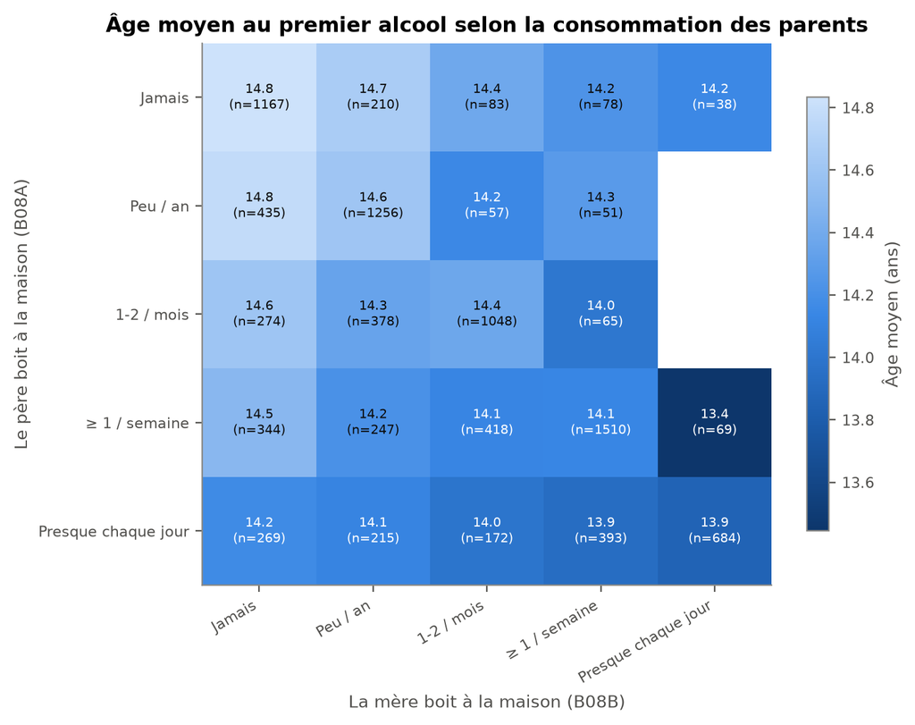

```python
m = clean & df["B08A"].notna() & df["B08B"].notna()
grid = pd.DataFrame({"pere": df["B08A"], "mere": df["B08B"], "y": y, "w": w})[m]
grid["yw"] = grid["y"] * grid["w"]
agg = grid.groupby(["pere", "mere"]).agg(yw=("yw", "sum"), w=("w", "sum"), n=("y", "size"))
heat = (agg["yw"] / agg["w"]).where(agg["n"] >= 30).unstack()
counts = agg["n"].unstack()

fig, ax = plt.subplots(figsize=(7, 5.5))
cmap = LinearSegmentedColormap.from_list("blue_ramp", BLUE_RAMP[::-1])  # foncé = précoce
im = ax.imshow(heat.values, cmap=cmap, aspect="auto")
for i in range(heat.shape[0]):
    for j in range(heat.shape[1]):
        v = heat.values[i, j]
        if not np.isnan(v):
            ax.text(j, i, f"{v:.1f}\n(n={counts.values[i, j]})", ha="center", va="center",
                    fontsize=7, color="white" if v < heat.stack().median() else "#0b0b0b")
labels = list(ALCOOL_PARENT.values())
ax.set_xticks(range(5), labels, rotation=30, ha="right")
ax.set_yticks(range(5), labels)
ax.set_xlabel("La mère boit à la maison (B08B)")
ax.set_ylabel("Le père boit à la maison (B08A)")
ax.set_title("Âge moyen au premier alcool selon la consommation des parents")
ax.grid(False)
fig.colorbar(im, ax=ax, label="Âge moyen (ans)", shrink=0.8)
plt.tight_layout()
plt.show()
```

Nous avons également observé la distribution de `l'âge de première consommation selon le sexe`. Si la majorité des filles comme des garçons consomment le premier verre d’alcool entre 14 et 16 ans on remarque que les garçons sont plus nombreux à consommer plus jeunes.

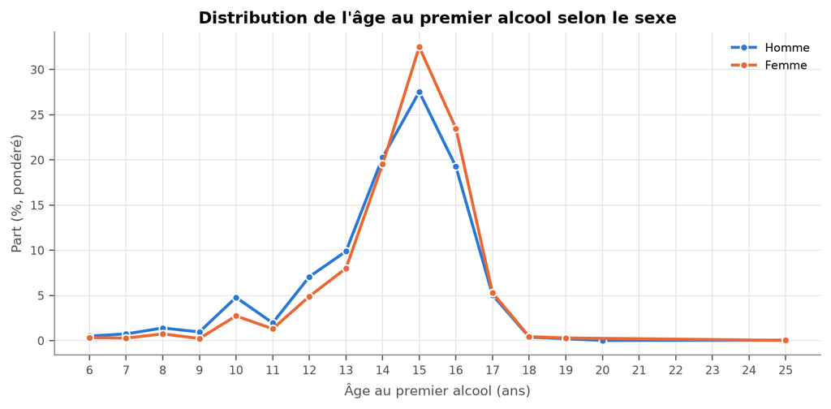

```python
fig, ax = plt.subplots(figsize=(8, 4))
for code, color in ((1, BLUE), (2, ORANGE)):
    m = clean & (df["Q03"] == code)
    d = pd.DataFrame({"age": y[m], "w": w[m]}).groupby("age")["w"].sum()
    d = d / d.sum() * 100
    ax.plot(d.index, d.values, color=color, linewidth=2, marker="o", markersize=5,
            markeredgecolor="white", label=VARIABLES["Q03"][1][code])
ax.set_xticks(range(AGE_MIN, AGE_MAX + 1))
ax.set_xlabel("Âge au premier alcool (ans)")
ax.set_ylabel("Part (%, pondéré)")
ax.set_title("Distribution de l'âge au premier alcool selon le sexe")
ax.legend()
plt.tight_layout()
plt.show()
```